# Homework 2

CS 498, Spring 2018, Xiaoming Ji

The UC Irvine machine learning data repository hosts a collection of data on adult income, donated by Ronny Kohavi and Barry Becker. You can find this data at https://archive.ics.uci.edu/ml/datasets/Adult For each record, there is a set of continuous attributes, and a class “less than 50K” or “greater than 50K”. There are 48842 examples. You should use only the continuous attributes (see the description on the web page) and drop examples where there are missing values of the continuous attributes. Separate the resulting dataset randomly into 10% validation, 10% test, and 80% training examples.

Firstly, we load and process data per the instructions.

```r
library(readr)
set.seed(19720816)

#Read data from 2 data files
data1 = read.csv("./data/adult.data", header = FALSE)[,c(1, 3, 5, 11, 12, 13, 15)]
data2 = read.csv("./data/adult.test", header = FALSE, skip = 1)[,c(1, 3, 5, 11, 12, 13, 15)]
```

Checking whether there are missing values.

```r
sum(!complete.cases(data1))
```

```
## [1] 0
```

```r
sum(!complete.cases(data2))
```

```
## [1] 0
```

- *No missing value found*

Merge these data and scale these variables so that each has unit variance. Then calculate the test/train split.

```r
data1[, 7] = as.numeric(data1[, 7])
data1[data1[, 7] == 1, 7] = -1
data1[data1[, 7] == 2, 7] = 1

data2[, 7] = as.numeric(data2[, 7])
data2[data2[, 7] == 1, 7] = -1
data2[data2[, 7] == 2, 7] = 1

adult_data = rbind(data1, data2)

#Normalize the data
for (i in 1:6) {
  s = sd(adult_data[,i])
  m = mean(adult_data[,i])

  adult_data[,i] = (adult_data[,i] - m) / s
}

#Calculate train/validation/test split
total_count = dim(adult_data)[1]
test_count = round(total_count * 0.1)
valid_count = round(total_count * 0.1)

test_indexes = sample(1:total_count,test_count)
```

We will write a function to do Stochastic Gradient Descent, by using the following formula. Its extension to text book’s example and add support to multiple sample $N_b$.
$$a^{(n+1)} = a^{n} - \frac{\eta}{N_b} (\sum_{i}^{N_b} \left\{\begin{matrix}
0&\text{if }y_i(a^Tx_i + b)\geq 1
\\-y_ix_i&otherwise
\end{matrix}\right. + \lambda a)$$
$$b^{(n+1)} = b^{n} - \frac{\eta}{N_b} \sum_{i}^{N_b} \left\{\begin{matrix}
0&\text{if }y_i(a^Tx_i + b)\geq 1
\\-y_i&otherwise
\end{matrix}\right.$$

Now, let’s write the function.

```r
predict = function(a, b, features) {
  pred_y = c(a %*% t(features) + b)
  pred_y[pred_y <= 0] = -1
  pred_y[pred_y > 0] = 1

  return (pred_y)
}

sgd = function(epoch, n_steps, sample_count, valid_count, heldout_count, steps_before_testing, data, parameters, lambda) {
  feature_count = dim(data)[2] - 1
  accuracy = c()
  w = c()
  v_a = parameters[1:feature_count]
  b = parameters[feature_count + 1]
  if(heldout_count > 0){
    heldout_accuracies = rep(0, epoch * n_steps / steps_before_testing)
    coef_magnitude     = rep(0, length(heldout_accuracies))
  } else {
    heldout_accuracies = NULL
    coef_magnitude     = NULL
  }

  if(valid_count > 0){
    valid_accuracies   = rep(0, epoch)
  } else {
    valid_accuracies   = NULL
  }

  total_step = 1
  test_count = 1

  for (epoch in 1:epoch) {
    #split heldout_data
    if(heldout_count > 0){
      heldout_indexes = sample(1: dim(data)[1], heldout_count)
      heldout_data = data[heldout_indexes,]
      #make the remaining the test and validation data
      r_indexes     = (1: dim(data)[1])[-heldout_indexes]
    } else {
      r_indexes     = (1: dim(data)[1])
    }

    train_indexes = sample(1:length(r_indexes), length(r_indexes) - valid_count)
    train_data  = data[r_indexes[train_indexes], ]
    if(valid_count > 0){
      valid_data  = data[r_indexes[-train_indexes],]
    }

    steplength  = 1 / (0.01 * epoch + 50)

    for (step in 1:n_steps){
      sample_indexes = sample(1:dim(train_data)[1], sample_count)
      x = train_data[sample_indexes, 1:feature_count]
      y = train_data[sample_indexes, feature_count + 1]

      h = y * (v_a %*% t(x) + b)

      #update a and b
      v_a = v_a - steplength/sample_count * (colSums(-y[h < 1] * x[h < 1,]) + lambda * v_a)
      b   = b - steplength/sample_count * sum(-y[h < 1])

      if(heldout_count > 0 && total_step %% steps_before_testing == 0){
        pred_y = predict(v_a, b, heldout_data[, 1:feature_count])
        heldout_accuracies[test_count] = sum(pred_y == heldout_data[, feature_count + 1]) / heldout_count
        coef_magnitude[test_count] = sqrt(t(v_a) %*% v_a)
        test_count = test_count + 1
      }
      total_step = total_step + 1
    }
    if(valid_count > 0) {
      #calculate accuracy on validation data
      pred_y = predict(v_a, b, valid_data[, 1:feature_count])
      valid_accuracies[epoch] =  sum(pred_y == valid_data[, feature_count + 1]) / length(pred_y)
    }
  }
  return (list(a = v_a, b = b,
               heldout_accuracies = heldout_accuracies,
               coef_magnitude = coef_magnitude,
               valid_accuracies = valid_accuracies))
}
```

## A plot of the accuracy every 30 steps, for each value of the regularization constant

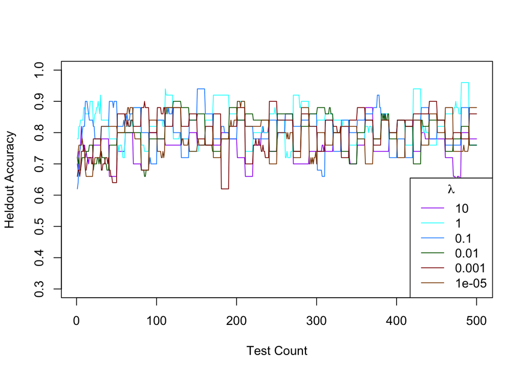

```r
lambdas =  c(10, 1, 1e-1, 1e-2, 1e-3, 1e-5)
params = runif(7, 0, 2)
results = list()

for (i in 1:length(lambdas)){
  results[[i]] = sgd(50, 300, 50, valid_count, 50, 30, adult_data[-test_indexes,], params, lambdas[i])
}

colors = c("purple", "cyan", "dodgerblue", "darkgreen", "darkred", "darkorange4")

plot(1:length(results[[1]]$heldout_accuracies), results[[1]]$heldout_accuracies, type = "l", ylim=c(0.3,1), xlab="Test Count", ylab="Heldout Accuracy", col=colors[1])

for (i in 2:length(lambdas)) {
  lines(1:length(results[[i]]$heldout_accuracies), results[[i]]$heldout_accuracies, col=colors[i])
}

legend("bottomright", title = expression(lambda), legend = lambdas, lwd = 1, col = colors)
```

## A plot of the magnitude of the coefficient vector every 30 steps, for each value of the regularization constant

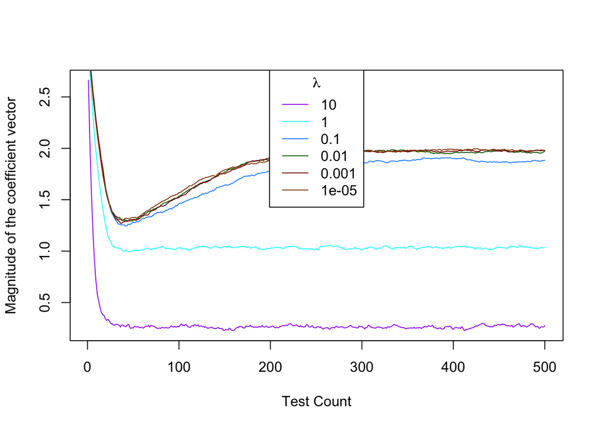

```r
plot(1:length(results[[1]]$coef_magnitude), results[[1]]$coef_magnitude, type = "l", xlab="Test Count", ylab="Magnitude of the coefficient vector", col=colors[1])

for (i in 2:length(lambdas)) {
  lines(1:length(results[[i]]$coef_magnitude), results[[i]]$coef_magnitude, col=colors[i])
}

legend("top", title = expression(lambda), legend = lambdas, lwd = 1, col = colors)
```

## Estimate of the best value of the regularization constant (together with a brief description of why you believe that is a good value)

Let’s make a boxplot of validation accuracy for each $\lambda$

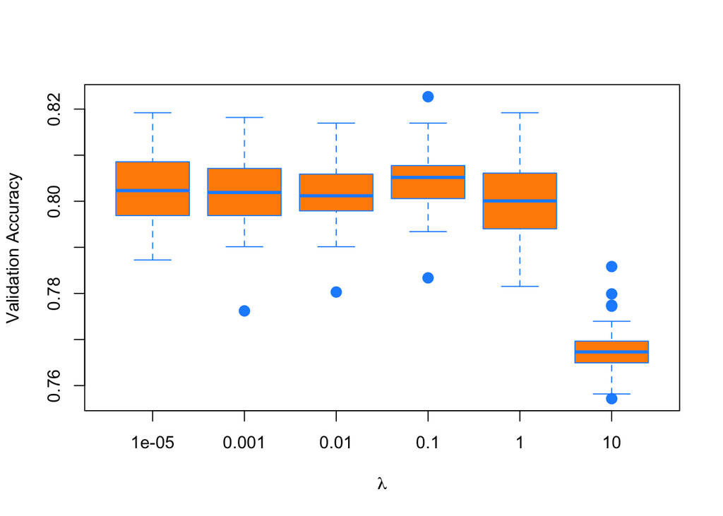

```r
df = data.frame()
for (i in 1:length(lambdas)){
  df = rbind(df, data.frame(y = results[[i]]$valid_accuracies, lambda=lambdas[i]))
}

boxplot(y ~ lambda, data = df, xlab=expression(lambda), ylab="Validation Accuracy", pch = 20, cex = 2, col = "darkorange", border = "dodgerblue")
```

By checking this plot, $\lambda = 0.1$ has the best mean of validation accuracy and relatively small magnitude of the coefficient vector (small coefficient means small hinge loss for unseen data). Thus, we choose *0.1* as our best $\lambda$.

## Estimate of the accuracy of the best classifier on the 10% test dataset data

```r
params = runif(7, 0, 2)

model = sgd(50, 300, 50, 0, 0, 0, adult_data[-test_indexes,], params, 0.1)
pred_y = predict(model$a, model$b, adult_data[test_indexes, 1:6])
accuracy = sum(pred_y == adult_data[test_indexes, 7]) / length(pred_y)
```

Accuracy: $0.8040541$